# Bitácora #1

CA-0303 Estadística Actuarial I

Autor/a

Oscar Espinoza, Gerardo Montero, Gabriel Robles, César Salazar

Fecha de publicación

30 de marzo de 2026

# Bitácora #1

## Planificación

### Pregunta de investigación

#### Definición de la idea

Idea: **“Se quiere identificar las características en las personas que más influyen en enfermedades cardíacas**

#### Conceptualización de la idea

De la idea anterior, se definen las palabras clave según la Real Academia Española (2026):

**Característica:** Cualidad que da carácter o sirve para distinguir a alguien o algo de sus semejantes.

**Influir:** Dicho de una cosa: Producir sobre otra ciertos efectos; como el hierro sobre la aguja imantada, la luz sobre la vegetación, etc.

Además, se define según la World Heart Federation (2023):

**Enfermedades Cardiovasculares:** Enfermedades que afectan al corazón o a los vasos sanguíneos (venas y arterias). Pueden estar causadas por una combinación de factores de riesgo socioeconómicos, conductuales y ambientales, como hipertensión arterial, dieta poco saludable, colesterol alto, diabetes, contaminación atmosférica, obesidad, tabaquismo, enfermedades renales, inactividad física, consumo nocivo de alcohol y estrés. *Los antecedentes familiares, el origen étnico, el sexo y la edad* también pueden afectar al riesgo de enfermedad cardiovascular de una persona.

#### Identificación de tensiones

1. Puede que el tamaño de la muestra no sen suficiente para concluir estadísticamente acerca de la influencia de ciertas variables en la presencia de enfermedades cardíacas. 2.Es posible que los valores de las variables estén muy dispersos y no se note una clara distinción en cuál variable influye realmente en tener la la presencia de alguna enfermedad cardíaca.
2. Según la WHF, son variables relevantes los antecedentes familiares y el origen étnico al momento de evaluar la posibilidad de tener problemas cardíacos, la ausencia de estas variables en el dataset limita el alcance explicativo del análisis.

#### Reformulación de la idea en forma de pregunta

1. ¿Qué importancia tiene conocer la influencia de ciertas características de personas en enfermedades cardíacas?
2. ¿Cómo influyen ciertas características de personas en enfermedades cardíacas?
3. ¿Cuáles son las características en personas que más influyen en enfermedades cardíacas?
4. ¿Qué patrones presentan estas características en personas con y sin enfermedades cardíacas?

#### Argumentación de la pregunta

***Pregunta 1** ¿Qué importancia tiene conocer la influencia de ciertas características de personas en enfermedades cardíacas?

**Lógica:**  
Conocer la importancia de estas características no necesariamente implica poder predecir o prevenir la enfermedad, ya que pueden existir variables ocultas o factores no medidos en el dataset.

**Ética:**  
El uso de datos médicos puede generar interpretaciones incorrectas si no se consideran contextos clínicos adecuados, lo que podría llevar a conclusiones irresponsables.

**Emocional:**  
La difusión de resultados sobre factores de riesgo puede generar ansiedad en las personas si se interpretan como determinantes absolutos de la enfermedad.

### Argumentos

**Lógica:**  
El análisis de variables como edad, colesterol y presión arterial permite identificar patrones asociados a enfermedades cardíacas, lo cual es fundamental en estudios poblacionales de la salud.

**Ética:**  
Trabajar con datos anonimizados y públicos permite realizar análisis responsables sin comprometer la privacidad de las personas.

**Emocional:**  
El conocimiento de factores de riesgo puede benerficiar a las personas para adoptar hábitos más saludables y tomar decisiones informadas sobre su salud.

### Conclusión

Conocer la influencia de ciertas características en enfermedades cardíacas es fundamental para la prevención y comprensión del problema. Aunque existen limitaciones en los datos y posibles interpretaciones erróneas, el valor informativo de este análisis justifica su estudio, especialmente en contextos donde la prevención es clave.

**Pregunta 2**

¿Cómo influyen ciertas características de personas en enfermedades cardíacas?

### Contraargumentos

**Lógica:**  
Los datos disponibles permiten identificar correlaciones, pero no necesariamente relaciones causales, lo que limita la interpretación de cómo influyen realmente las variables.

**Ética:**  
La simplificación de la influencia de variables podría llevar a conclusiones reduccionistas, ignorando factores sociales, genéticos o ambientales no incluidos en el dataset, por la diversidad de posibilidades.

**Emocional:**  
Las personas podrían asumir que ciertas características determinan su condición de salud, lo que puede generar fatalismo o decisiones equivocadas.

### Argumentos

**Lógica:**  
A través de métodos estadísticos como regresión o análisis de correlación, es posible identificar el grado de asociación entre variables y la presencia de enfermedades cardíacas.

**Ética:**  
El uso de datos estructurados y documentados permite realizar análisis transparentes y replicables, garantizando la integridad del estudio.

**Emocional:**  
Comprender cómo influyen las variables permite comunicar mejor los riesgos y fomentar cambios positivos en el estilo de vida de las personas.

### Conclusión

Si bien los datos no permiten establecer causalidad directa, sí es posible analizar cómo influyen ciertas características en enfermedades cardíacas mediante relaciones estadísticas. Este enfoque aporta valor al entendimiento del problema, siempre que se interprete con cautela y dentro de sus limitaciones.

**Pregunta 3** ¿Cuáles son las características en personas que más influyen en enfermedades cardíacas?

#### Contraargumentos de la pregunta:

**Lógica:**  
La identificación de las características más influyentes depende del método utilizado, lo que puede generar resultados distintos y dificultar determinar cuáles variables son realmente las más relevantes.

**Ética:**  
El dataset puede no ser representativo de toda la población, lo que introduce sesgos en los resultados.

**Emocional:**  
Las personas podrían interpretar erróneamente los resultados y generar preocupación innecesaria sobre su salud.

#### Argumentos

**Lógica:**  
Mediante análisis estadísticos como correlación y modelos de clasificación, es posible identificar variables con mayor peso en la predicción de enfermedades cardíacas de acuerdo a los datos.

**Ética:**  
El uso de datos públicos y anonimizados provenientes de sitios conocidos por ser usados para bases de datos, como es el caso de kaggle, garantiza que no se vulnera la privacidad de los individuos.

**Emocional:**  
El análisis puede contribuir a la concientización sobre factores de riesgo y promover hábitos saludables.

#### Conclusión

El análisis de las características más influyentes en enfermedades cardíacas es viable mediante herramientas estadísticas y de aprendizaje automático. Sin embargo, los resultados deben interpretarse con cautela debido a posibles sesgos y a la naturaleza no causal de los datos. Aun así, este estudio puede aportar valor en la identificación de factores de riesgo relevantes.

#### Argumentación a través de datos

#### Audiencia del proyecto

### Revisión bibliográfica

Sobre el tema de los problemas cardiovasculares en el ambiente de la estadística se ha escrito una gran cantidad de artículos. Entre ellos, uno de los más destacados es la obra de Gill et al. (2005) (Why Clinitians are natural Bayesian); que a pesar de la edad del artículo, provee detalles de por qué el enfoque bayesianoes mejor usarse en lugar del enfoque clásico. De acuerdo a Gill et al. (2005) “El enfoque bayesiano no devuelve una respuesta de sí o no, sino una probabilidad condicional que refleja el contexto en el que el se hace la prueba”. Por lo tanto, el enfoque bayesiano tiene la ventaja de que el contexto cambia las conclusiones que se pueden extraer para los datos. La diferencia entre estos dos se va a profundizar aún más en el marco teórico de esta investigación, pero este artículo es fundamental para comprender por qué se usa el enfoque bayesiano sobre el clásico o frecuentista.

Además de este artículo, hay más que explican por qué se prefiere el enfoque bayesiano para datos como estos. Entre estos, el articulo de Lorca & Águila (2024) *Inferencia Bayesiana en el proceso de diagnóstico clínico: un enfoque docente para la toma de decisiones* es una obra mucho más reciente que la anterior, en particular algo llamativo es su metodología, pues usan una modificación del Teorema de Bayes:

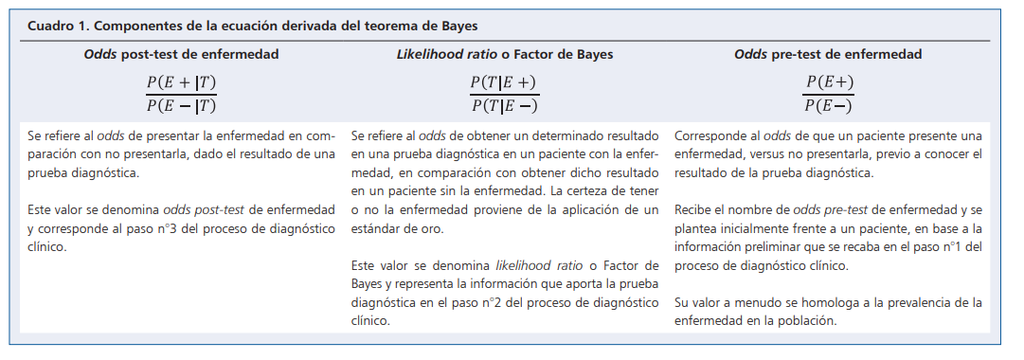

Metodología de Lorca & Águila (2024)

#### Fichas de literatura

### UVE de Gowin

## Parte de escritura

## Arco narrativo del proyecto

“El problema que nadie ha resuelto completamente aún es identificar con claridad cuáles características individuales tienen mayor influencia en las enfermedades cardíacas a partir de los datos”

### Posicionamiento del equipo

## Diario de aprendizaje

Como equipo, hemos aprendido que el análisis de datos no comienza con la aplicación de métodos, sino con la correcta formulación de una pregunta de investigación alineada con los datos disponibles y de esta forma tener claro cual camino seguir. Al inicio no teníamos claro cómo delimitar una idea en un problema investigable, pero ahora entendemos la importancia de estructurar el enfoque del proyecto desde etapas tempranas, para asi que el flujo de trabajo vaya en la mejor forma. También comprendimos que los datos observacionales no permiten establecer relaciones causales, sino asociaciones, lo que influye directamente en la interpretación de los resultados. Además, identificamos que las limitaciones del dataset condicionan el alcance del análisis. Finalmente, aprendimos que la toma de decisiones es un proceso clave que impacta el desarrollo del proyecto, ya que debido a esto se define cómo se analiza la información y qué conclusiones se pueden obtener.

## Rastro de decisiones

### Decisión 1: Uso del dataset

- Opciones consideradas:
  - Buscar múltiples datasets
  - Utilizar un único dataset de Kaggle
- Opción elegida:
  - Dataset de Kaggle sobre enfermedades cardíacas
- Opciones descartadas:
  - Integración de múltiples fuentes de datos
- Justificación:
  - El dataset de Kaggle es accesible, estructurado y contiene variables relevantes para el análisis, lo que permite avanzar de forma eficiente sin necesidad de procesos complejos de integración de datos, además de ser proveniente de una fuente confiable y de uso sencillo y un tema adecuado.

### Decisión 2: Enfoque del proyecto

- Opciones consideradas:
  - Construir un modelo predictivo de enfermedades cardíacas
  - Analizar la relación entre variables y la enfermedad
- Opción elegida:
  - Análisis de la relación entre características y enfermedades cardíacas
- Opciones descartadas:
  - Modelo predictivo completo
- Justificación:
  - El desarrollo de modelos predictivos requiere herramientas y conocimientos más avanzados (machine learning) que no son parte del curso. Por ello, y recomendacion del profesor, se decidió enfocarse en un análisis exploratorio y descriptivo que permita identificar relaciones relevantes entre variables.

### Decisión 3: Selección de la pregunta de investigación

- Opciones consideradas:
  - ¿Qué importancia tiene conocer estas características?
  - ¿Cómo influyen estas características?
  - ¿Cuáles características influyen más?
  - ¿Qué patrones presentan estas características?
- Opción elegida:
  - ¿Cuáles son las características en personas que más influyen en enfermedades cardíacas?
- Opciones descartadas:
  - Preguntas demasiado generales o conceptuales
- Justificación:
  - La pregunta seleccionada permite un análisis directo con los datos disponibles, facilitando la identificación de variables relevantes mediante métodos estadísticos, además de ser la que nos sonó mas acertada.

## Registro de uso de AI

Para la argumentacion de logica, etica y emocional, se usó IA de forma que se le daban las preguntas y se le pedia que hiciera argumentos y contraargumentos de las debidas partes, para de esta manera comprender que tipo de respuestas son las adecuadas de acuerdo a cada elemento, despues, dada la respuesta de la IA, se acomodan sus respuestas para que tenga un tono mas natural y ser capaces de comprenderlo en nuestras palabras.

## Log de contribuciones

## Marco teórico

Para esta investigación se van a utilizar conceptos fundamentales de la estadística y probabilidad que influyen el proceso en los factores de riesgo en ciertas demografías. A continuación se va a elaborar no solamente los enfoques probabilísticos y estadísticos para la investigación sino también otros conceptos no completamente relacionados a esos. El presente reporte articula un marco teórico exhaustivo que responde a la necesidad de identificar patrones, jerarquizar influencias y modelar la probabilidad de eventos adversos, integrando la estadística clásica con las fronteras del aprendizaje automático y la inferencia causal.

En primer lugar, se deben introducir ciertas definiciones básicas de estadística antes de profundizar los enfoques que se van abordar.

De acuerdo a DeGroot & Schrevish (2012) , Suponga que la cantidad observable de variables aleatorias de interés son $X₁,\cdots,X_n$. Sea r una función arbitraria con valores reales. Entonces la variable aleatoria $T = r(X_1 ,\cdots, X_n )$ es un **estadístico**. Tres ejemplos de estadísticos son la media aritmética $\bar{Xn}$, el máximo $Yn$ de los valores $X_1,\cdots,X_n$ y la función $r(X_1 ,\cdots, X_n )$, que tiene el valor constante de 3 para todos los valores de $X_1 ,, X_n $. (p. 382) Un estadístico entonces es una función que conjuga una cantidad definida de variables aleatorias y devuelve un número real. Para efectos de esta investigación, es un concepto integral para las siguientes definiciones ya que se utiliza para inferir propiedades de una población.

De la misma obra, se van a definir dos conceptos adicionales a éstos. La **distribución previa** por ejemplo, Suponga que uno tiene un modelo estadístico con parametro theta. Si uno trata theta como aleatorio entonces la distribución que le da a theta antes de observar las otras variables aleatorias de interés. Eso se llama la distribución previa. Si el espacio donde está theta es contable, entonces la distribución previa es discreta y se refiere como *p.f. previa*, si theta es continua, se refiere como *p.d.f previa* pues sería continua la distribución previa. Se va a denotar xi(theta) como ambas p.f y p.d.f en función de solo theta. (p. 385) La distribución previa es una función de una variable theta, donde theta es el parámetro de la distribución de una variable aleatoria de interés, que a priori se sabe su distribución. Nota: de ahora en adelante, se va a referir a $\xi(\theta)$ como $\pi(\theta)$.

Después sigue la **distribución posterior** que se demuestra como La distribución condicional de theta dado x1,…,xn. La p.f. o p.d.f. de theta dado x1 = x1,…, xn = xn sellama la p.f. posterior o p.d.f. posterior y se denota $\xi(\theta|x1,..,xn)$. (…) Si se supone que este parametro theta es desconocido y la p.f o p.d.f previa de theta es $\xi(\theta)$. Entonces la p.d.f o p.f. posterior de es
$$\begin{align*}
\xi(\theta | \mathbf{x}) = \frac{f(x_1| \theta) \cdots f(x_n | \theta) \xi(\theta)}{g_n(\theta)}; \quad \theta \in \Omega \\
donde g_n = \idotsint_{\Omega_{X_1}, \cdots, \Omega_{X_n}}f( x_1| \theta) \cdots f(x_n | \theta) \xi(\theta)
\end {align*}$$
(p. 387-388) Luego en la página 388, el denominador de la posterior se define como la **p.f. o p.d.f junta marginal de $X_1, \cdots, X_n$**, y se denota por $g_n(x)$, El numerador de la posterior se define como la **verosimilitud** y se denota por $\mathcal{L}(\theta | \mathbb{x})$. Similarmente a la previa, la distribución posterior ($\xi (\theta | \mathbf{x})$)se va a denotar de ahora en adelante como $\pi(\theta | \mathbf{x})$

El **enfoque clásico o frecuentista** consiste en La idea de que, si un experimento fuese a ser replicado una gran cantidad de veces, se puede establecer una distribución de muestra de un estadístico específico, como $\bar{X_d}$. Se reconoce que el valor que se obtiene cada vez será diferente cuando se repite el experimento porque los participantes totales siempre cambian (…) Dado la distribución de $\bar{X_d}$, se puede estimar el exento de la variabilidad, el error o la desviación del estadístico $\mu_d$. Pek & Van Zandt (2019) Asimismo, el frecuentista establece que al tener datos grandes, los estadísticos cambian cada vez que se suman datos nuevos, por lo que se usan datos históricos para definir estos nuevos estadísticos. Este enfoque tiene sus ventajas al tener datos más grandes, más repetibles y con mejores datos históricos.

El **enfoque bayesiano** es completamente diferente al clásico pues En lugar de la distribución de $X_d$, el enfoque bayesiano usa la distribución posterior del parámetro de éstos. Como se ha describido, la posterior depende de la selección de la distribución previa del parámetro y la verosimilitud. Por ejemplo, si se toma datos que siguen una distribución normal con media $\mu$ y desviación estándar 0; y si además se escoje una distribución previa para $\mu$ de media 1 y desviación 0, tendrá una posterior con media .41 y desviación $\sqrt{2}$ (Bolstad, 2010). Usando esta posterior, se pueden calcular las probabilidades de que $\mu$ tome valores dentro de un intervalo de interés.

La diferencia mayor entre ambos es claramente el uso de la posterior. Por lo que el enfoque bayesiano y clásico ambos crean intervalos en los que puede “vivir” el parámetro, la manera en que se construye es muy diferente. De una manera resumida, el enfoque bayesiano usa la distribución previa de los parámetros para crear un **intervalo creíble de Bayes** donde se estima que 95% de estos parámetros podrían estar ubicados ahí, mas el enfoque clásico usa estadísticos “viejos” y los varía a través de un **intervalo de confianza**, donde se estima que 95% de los valores posibles del parámetro pueden llegar a estar ahí.

## Referencias

DeGroot, M., & Schrevish, M. (2012). *Probability & Statistics* (4.ª ed.). Pearson. https://educationexclusive.com/upload/pdf/Probability%20and%20Statistics%20by%20Morris%20H.%20DeGroot%20and%20Mark%20J.%20Schervish.pdf

Gill, C. J., Sabin, L., & Schmid, C. H. (2005). Why clinicians are natural bayesians. *BMJ*, *330*(7499), 1080-1083. https://doi.org/10.1136/bmj.330.7499.1080

Lorca, J. C., & Águila, L. C. (2024). Inferencia Bayesiana en el proceso de diagnóstico clínico: un enfoque docente para la toma de decisiones. *Revista Chilena de Infectología*, *41*(6), 762-768. https://doi.org/10.4067/s0716-10182024000600168

Pek, T., & Van Zandt, T. (2019). Frequentist and Bayesian approaches to to data analysis: Evaluation and estimation. *SageJournals*, *19*(1). https://doi.org/10.1177/1475725719874542

Real Academia Española. (2026). *Diccionario de la lengua española*. https://dle.rae.es

World Heart Federation. (2023). *Enfermedades cardiovasculares (ECV)*. https://world-heart-federation.org/es/what-is-cvd/